# Explanations of Model Predictions with live and breakDown Packages

Mateusz Staniak

Faculty of Mathematics and Information Science, Warsaw University of Technology

Przemysław Biecek

Faculty of Mathematics and Information Science, Warsaw University of Technology

2018-12-11

Abstract

Complex models are commonly used in predictive modeling. In this paper we present R packages that can be used for explaining predictions from complex black box models and attributing parts of these predictions to input features. We introduce two new approaches and corresponding packages for such attribution, namely *live* and *breakDown*. We also compare their results with existing implementations of state-of-the-art solutions, namely, *lime* (Pedersen and Benesty 2018) which implements *Locally Interpretable Model-agnostic Explanations* and *iml* (Molnar, Bischl, and Casalicchio 2018) which implements *Shapley values*.

This article is converted from a Legacy LaTeX article using the texor package. The pdf version is the official version. To report a problem with the html, refer to CONTRIBUTE on the R Journal homepage. This article includes tables which may not be properly formatted. This article includes figures which have not been given correct alternative text.

# Introduction

Predictive modeling is a very exciting field with a wide variety of applications. Lots of algorithms have been developed in this area. As proven in many Kaggle competitions (Fogg 2016), winning solutions are often obtained with the use of elastic tools like random forest, gradient boosting or neural networks. Many of them are implemented by R packages found in the CRAN Task View [*MachineLearning*](https://CRAN.R-project.org/view=MachineLearning).

These algorithms have many strengths but they also share a major weakness, which is a deficiency in interpretability of a model structure. A single random forest, an xgboost model or a neural network may be parameterized with thousands of parameters which make these models hard to understand. Lack of interpretability results in the lack of trust in model predictions. Lack of trust is a major obstacle when one thinks about applications in regulated areas such as personalized medicine or similar fields. An interesting example of a situation in which trust issues are fully justified is presented in (Ribeiro, Singh, and Guestrin 2016). Authors compare two classifiers that were trained to recognize whether a text describes Christianity or Atheism. After explanations were provided, it turned out that the model with superior performance in the test set often based its prediction on irrelevant words, for example, prepositions. To overcome this problem, the interpretability of complex machine learning models has been a subject of much research, devoted partially also to model visualization (Štrumbelj and Kononenko 2011; Tzeng and Ma 2005; Zeiler and Fergus 2014).

The general approach to interpretability is to identify important variables (features) in the model and then learn the expected model response for a single variable. A description of a general framework of permutation-based variable importance rankings may be found in (Altmann et al. 2010). An interesting and widely adopted tool for estimation of marginal model response is *Partial Dependency Plot* (J. H. Friedman 2001), that presents the marginal relationship between the variable of interest and a single variable from the model. An effective and very elastic implementation of this method is available in the [*pdp*](https://CRAN.R-project.org/package=pdp) package (Greenwell 2017). This method has many extensions such as for example *Individual Conditional Expectations* (Goldstein et al. 2015). The ICE method allows for tracing predictions for individual variables and it is very useful for the identification of interactions. On the other hand, ALE plots (Apley 2016) were proposed as a superior tool for handling strongly correlated predictors by describing the conditional distribution of predicted values. This method can be used to assess both main effects and interactions between predictors. All these methods are focused on the effect of a single variable or small set of variables within the black box model.

A different approach is presented by (Ribeiro, Singh, and Guestrin 2016). While methods such as PDP and ALE plot aim to describe model behavior globally, it is also possible to explain individual predictions as in ICE. We will focus on such methods. The authors propose LIME (*Locally Interpretable Model agnostic Explanations*) as a method for explaining black box predictions by fitting an interpretable model locally around a prediction of interest. This methodology was illustrated with examples from image and text classification areas. Later, it was extended by (Puri et al. 2017) to MAGIX methodology (*Model Agnostic Globally Interpretable Explanations*) and modified by the authors of the original article to aLIME (*anchor-LIME*) by (Tulio Ribeiro, Singh, and Guestrin 2016).

So far, two implementations of the method have been found. Python library was developed by the authors of the original article and it is available on GitHub at https://github.com/marcotcr/lime. It works for any text or image classifier as well as for tabular data. Regression models can be explained using simple linear regression. The R package [*lime*](https://CRAN.R-project.org/package=lime) is a port to the original Python package. This package works with tabular and text data and handles all models supported by either [*caret*](https://CRAN.R-project.org/package=caret) (Kuhn 2018) or [*mlr*](https://CRAN.R-project.org/package=mlr) (Bischl et al. 2016) package and it can be easily extended to work with other models. An implementation of the *sp-LIME* algorithm proposed in the original article to choose representative observations that would explain the behavior of the model globally is available for Python.

In addition to packages that implement single methods, in R we have also two packages with a consistent collection of explainers: [*DALEX*](https://CRAN.R-project.org/package=DALEX) (Biecek 2018) and [*iml*](https://CRAN.R-project.org/package=iml).

In this article, we give a short overview of methods for explaining predictions made by complex models. We also introduce two new methods implemented in R packages [*live*](https://CRAN.R-project.org/package=live) and [*breakDown*](https://CRAN.R-project.org/package=breakDown). Examples presented in this paper were recorded with the [*archivist*](https://CRAN.R-project.org/package=archivist) package (Biecek and Kosinski 2017). They can be accessed and restored with a single R instruction listed in footnotes.

# Related work

In this section we present two of the most recognized methods for explanations of a single prediction from a complex black box model (so-called instance-level explanations).

### Locally Interpretable Model-agnostic Explanations (LIME)

(Ribeiro, Singh, and Guestrin 2016) proposed **LIME** method for explaining prediction for a single observation. The algorithm is designed to explain predictions of any classifier and it works primarily for image and text data. First, original observation of interest is transformed into simplified input space of binary vectors (for example presence or absence of words). Then a dataset of similar observations is created by sampling features that are present in the representation of the explained instance. The closeness of these observations to the original observations is measured via a specified similarity kernel. This distance is taken into account while the explanation model is fitted to the new dataset. The interpretable model can be penalized to assure that it does not become too complex itself. In mathematical terms, LIME explanation for observation $x$ is a model $g$ which approximates complex model $f$ by solving the following optimization problem
$$g(\cdot) = \arg \min_{h
\in G}\bigg[\mathcal{L}(f, h, \pi_{x}(z)) + \Omega(h)\bigg],$$
where $z$ is the interpretable (binary) representation of $x$, $\pi_{x}(z)$ is a measure of closeness of $z$ and $x$ (the kernel), $\mathcal{L}$ is a loss function that measures local faithfulness of the explanation and $\Omega$ is a model complexity measure, that serves as a regularization term.

## Shapley values (SHAP)

In 2017 (Lundberg and Lee 2017) introduced a general framework for explaining machine learning models that encompasses LIME among other methods. The method is associated with some specific visualization techniques that present how predictors contribute to the predicted values. In this framework, observations are transformed into the space of binary variables called simplified inputs. Explanation models are restricted to the so-called **additive feature attributions methods**, what means that values predicted by the explanation model are linear combinations of these binary input vectors. Formally, if $z = (z_{1}, \ldots, z_{p})$ is a binary vector in simplified inputs space and $g$ is the explanation model, then
$$g(z) = \phi_{0} + \sum_{j =
1}^{M}\phi_{j}z_{j},$$
where $\phi_{j}, j = 0, \ldots, M$ are weights. These weights measure how each feature contributes to the prediction. Authors prove that in this class of explanation models **Shapley values** provide unique solutions to the problem of finding optimal weights $\phi_{j}$ that assure that the model has desirable properties of local accuracy and consistency. For formal treatment and examples, please refer to the original article of (Lundberg and Lee 2017). In particular, you will find there a proof that for certain choices of parameters in the LIME method, coefficients of the fitted local linear model are Shapley values. The Python implementation of this method is available at https://github.com/slundberg/shap. In R *Shapley values* can be found in few packages. For tree based models they are implemented in [*xgboost*](https://CRAN.R-project.org/package=xgboost) package (Chen et al. 2018). An independent model agnostic implementation is available in the *iml* package. A development version of a package dedicated entirely to Shapley values can be found at https://github.com/redichh/ShapleyR.

# Local Interpretable Visual Explanations (LIVE)

The next two sections introduce two new approaches to explaining model prediction, implemented in R packages *live* and *breakDown*, respectively. Both of these methods describe locally (at an instance level) how features contribute to a model prediction.

## Motivation

*live* is an alternative implementation of LIME for regression problems, which emphasizes the role of model visualization in the understanding of complex models. In comparison with the original LIME, both the method of local exploration and handling of interpretable inputs are changed. A dataset for local exploration is simulated by perturbing the explained instance one feature at a time. The process is described in section 3.2. By default, the Gaussian kernel is used to measure distances between simulated observation and the observation of interest, but other kernels can also be used, too. Original variables are used as interpretable inputs, so numerical features are used in the explanation model. Interpretability of the local explanation comes from a tractable relationship between inputs and the predicted response. Variable selection is optional for linear regression when sparsity is required.

One of the main purposes of *live* is to provide tools for model visualization, which is why in this package emphasis is put on models that are easy to visualize. For linear models, waterfall plots can be drawn to present how predictors contribute to the overall model score for a given prediction, while forest plots (Kennedy 2017) can be drawn to summarize the structure of local linear approximation. Examples clarifying both techniques are given in section 5. Other interpretable models that are equipped with generic `plot` function can be visualized, too. In particular, decision trees which can be plotted using [*party*](https://CRAN.R-project.org/package=party) package (Strobl et al. 2008) are well suited for this task, as they can help discover interactions. An example is given in section 5. The package uses the *mlr* interface to handle machine learning algorithms, hence any classifier or regression method supported by *mlr* can be used as an interpretable model, though in practice simple models will be preferred. The most common choice is a sparse linear model.

## Methodology

*live* package uses a two-step procedure to explain prediction of a selected black box model in the point $x$. First, an artificial dataset $X'$ is created around point $x$. Then, the white box model is fitted to the model predictions for points in $X'$.

The first step is described by the Algorithm 1.

1. $p \gets \text{number of predictors}$
2. $m \gets \text{number of observations to generate}$
3. $\text{Duplicate the given observation } m \text{ times}$
4. for i in $\{1, \ldots, m\}$ do
5. Draw number $k \in \{1, \ldots, p\}$ uniformly. Replace the value of $k$-th variable in i-th duplicate with a random draw from the empirical distribution of this variable in the original dataset
6. end for

Algorithm 1: Simulating *X*′ - surroundings around the selected *x*.

In other words, the procedure amounts to iterating over the set of $m$ observations identical to a given instance and changing the value of one random variable at each step. Alternatively, in *live* package new dataset can be sampled from a multivariate normal distribution and using permutations of each column. Details can be found in the manual. Current implementation of this algorithm relies on [*data.table*](https://CRAN.R-project.org/package=data.table) package for performance (Dowle and Srinivasan 2017). The choice of the number of instances to sample is an open problem both in LIME and LIVE methods.

# Model agnostic greedy explanations of model predictions (breakDown)

## Motivation

*live* package approximates the local structure of the black box model around a single point in the feature space. The idea behind the *breakDown* is different. In the case of that package, the main goal is to decompose model predictions into parts that can be attributed to particular variables. It is straightforward for linear (and more generally: additive) models. Below we present a model agnostic approach that works also for nonlinear models.

Let us use the following notation: $x = (x_1, x_2, ..., x_p) \in X \subset \mathcal R^p$ is a vector in feature space $X$. $f:X \rightarrow R$ is a scoring function for the model under consideration, that may be used for regression of classification problems. $X^{train}$ is a training dataset with $n$ observations.

For a single observation $x^{new}$ the model prediction is equal to $f(x^{new})$. Our goal is to attribute parts of this score to variables (dimensions) in the $X$ space.

## The lm-break: version for additive models

For linear models (and also generalized linear models) the scoring function (e.g. link function) may be expressed as a linear combination of feature vectors.

$$f(x^{new}) = (1, x^{new}) (\mu, \beta)^T
= \mu + x^{new}_1 \beta_1 + \ldots + x^{new}_p \beta_p.
\label{eq:linearmodel} (\#eq:linearmodel)$$

In this case it is easy to attribute the impact of feature $x_i$ to prediction $f(x^{new})$. The most straightforward approach would be to use the $x^{new}_i \beta_i$ as the attribution. However, it is easier to interpret variable attributions if they are invariant to scale-location transformations of $x_i$, such as change of the units or origin. Centering addresses location changes and scaling also changes the scales of $\beta$ parameters. This is why for linear models the **lm-break** variable attributions are defined as $(x^{new}_i - \bar x_i) \beta_i$. The equation @ref(eq:linearmodel) may be rewritten as follows:

$$f(x^{new}) = (1, x^{new}) (\mu, \beta)^T
= baseline + (x^{new}_1 - \bar x_1) \beta_1 + ... + (x^{new}_p - \bar
x_p) \beta_p$$

where
$$baseline = \mu + \bar x_1 \beta_1
+ ... + \bar x_p \beta_p.$$

Components $(x^{new}_i - \bar x_i) \beta_i$ are all expressed in the same units. For `lm` and `glm` models these values are calculated and plotted by the generic `broken()` function from the *breakDown* package.

## The ag-break: model agnostic approach

Interpretation of **lm-break** attributions is straightforward but limited only to additive models. In this section, we present an extension for non-additive models. This extension uses additive attributions to explain predictions from non-additive models thus some information about the model structure will be lost. Still, for many models, such attribution may be useful. For additive models the **ag-break** approach gives the same results as **lm-break** approach.

The intuition behind **ag-break** approach is to identify components of $x^{new}$ that cannot be changed without a significant change in the prediction $f(x^{new})$. In order to present this approach in a more formal way, we first need to introduce some definitions.

**Definition 1** (Relaxed model prediction). Let $f^{IndSet}(x^{new})$ denote an expected model prediction for $x^{new}$ relaxed on the set of indexes $IndSet \subset \{1, \ldots, p\}$.
$$f^{IndSet}(x^{new}) = E[f(x)|x_{IndSet} =
x^{new}_{IndSet}].$$
Thus $f^{IndSet}(x^{new})$ is an expected value for model response conditioned on variables from set $IndSet$ in such a a way, that $\forall_{i\in IndSet} x_i = x^{new}_i$.

The intuition behind relaxed prediction is that we are interested in an average model response for observations that are equal to $x^{new}$ for features from $IndSet^C$ set and follow the population distribution for features from $IndSet$ set. Clearly, two extreme cases are
$$f^{\{1, \ldots, p\}}(x^{new}) =
f(x^{new}),$$
which is the case of no relaxation, and
$$f^{\emptyset}(x^{new}) = E [f(x)].$$
which corresponds to full relaxation. We will say that a variable was relaxed when we do not fix its value and we let it follow the population distribution. This will play a crucial part in the algorithm presented in this section.

Since we do not know the joint distribution of $x$, we will use its estimate instead.
$$\widehat {f^{IndSet}(x^{new})} = \frac 1n
\sum_{i = 1}^n f(x^i_{-IndSet},x^{new}_{IndSet}).$$
We will omit the dashes to simplify the notation.

**Definition 2** (Distance to relaxed model prediction). Let us define the distance between model prediction and relaxed model prediction for a set of indexes $IndSet$.
$$d(x^{new}, IndSet) := |f^{IndSet}(x^{new}) -
f(x^{new})|.$$

It is the difference between model prediction for observation $x^{new}$ and observation relaxed on features $indSet$. The smaller the difference, the less important are variables in the $indSet$ set.

**Definition 3** (Added feature contribution). For j-th feature we define its contribution relative to a set of indexes $IndSet$ (*added contribution*) as
$$\text{contribution}^{IndSet}(j) = f^{IndSet
\cup \{j\}}(x^{new}) - f^{IndSet}(x^{new}).$$
It is the change in model prediction for $x^{new}$ after relaxation on $j$.

The model agnostic feature contribution is based on distances to relaxed model predictions. In this approach, we look for a series of variables that can be relaxed in such a way so as to move model prediction from $f(x^{new})$ to a fully relaxed prediction $E [f(x)]$ (expected value for all model predictions). The order of features in this series is important. But here we use a greedy strategy in which we add features to the $indSet$ iteratively (one feature per iteration) and minimize locally the distance to relaxed model prediction.

This approach can be seen as an approximation of Shapley values where feature contribution is linked with the average effect of a feature across all possible relaxations. These approaches are identical for additive models. For non-additive models, the additive attribution is just an approximation in both cases, yet the greedy strategy produces explanations that are easier to interpret. It is worth noting that similar decomposition of predictions and measures of contribution for classifiers have been examined in (Robnik-Šikonja and Kononenko 2008).

The greedy search can start from a null set of indexes (then in each step a single feature is being relaxed) or it can start from a full set of relaxed features (then in each step a single feature is removed from the set). The above approaches are called *step-up* and *step-down*, respectively. They are presented in algorithms 2 and 3.

The algorithm 2 presents the procedure that generates a sequence of variables with increasing contributions. This sequence corresponds to variables that can be relaxed in such a way so as to minimize the distance to the original prediction. The resulting sequence of $Contributions$ and $Variables$ may be plotted with Break Down Plots, see an example in Figure 2. Figure 1 summarizes the idea behind algorithm 2. By relaxing consecutive variables one finds a path between single prediction and average model prediction.

One can also consider an opposite strategy - instead of starting from $IndSet = \{1, \ldots, p\}$ one can start with $IndSet = \emptyset$. That strategy is called *step-up* approach and it is presented in Algorithm 3.

Note that the Break Down method is also available for Python in the `pyBreakDown` library.[^1]

1. $p \gets \text{number of variables}$
2. $IndSet \gets \{1, \ldots, p\} \text{ set of indexes of all variables}$
3. for i in $\{1, \ldots, p\}$ do
4. Find new variable that can be relaxed with small loss in relaxed distance to $f(x^{new})$
5. for j in $IndSet$ do

6. ```
      Calculate relaxed distance with $j$ removed
   ```

7. ```
      $dist(j) \gets d(x^{new}, IndSet \setminus \{j\})$
   ```

8. end for
9. Find and remove $j$ that minimizes loss
10. $j_{min} \gets \text{arg}\min_j dist(j)$
11. $Contribution^{IndSet}(i) \gets f^{IndSet}(x^{new}) - f^{IndSet \setminus \{j_{min}\}}(x^{new})$
12. $Variables(i) \gets j_{min}$
13. $IndSet \gets IndSet \setminus \{j_{min}\}$
14. end for

    Algorithm 2: Model agnostic break down of model predictions. The *step-down* approach.

15. $p \gets \text{number of variables}$
16. $IndSet \gets \emptyset \text{ empty set}$
17. fori in $\{1, \ldots, p\}$ do
18. Find new variable that can be relaxed with large distance to $f^{\emptyset}(x^{new})$
19. for j in $\{1, \ldots, p\} \setminus IndSet$ do

20. ```
       Calculate relaxed distance with $j$ added
    ```

21. ```
       $dist(j) \gets d(x^{new}, IndSet \cup \{j\})$
    ```

22. end for
23. Find and add $j$ that maximize distance 10.$j_{max} \gets \text{arg}\max_j dist(j)$
24. $Contribution^{IndSet}(i) \gets f^{IndSet \cup \{j_{max}\}}(x^{new}) - f^{IndSet}(x^{new})$
25. $Variables(i) \gets j_{max}$
26. $IndSet \gets IndSet \cup \{j_{max}\}$
27. end for

Algorithm 3: Model agnostic break down of model predictions. The *step-up* approach.

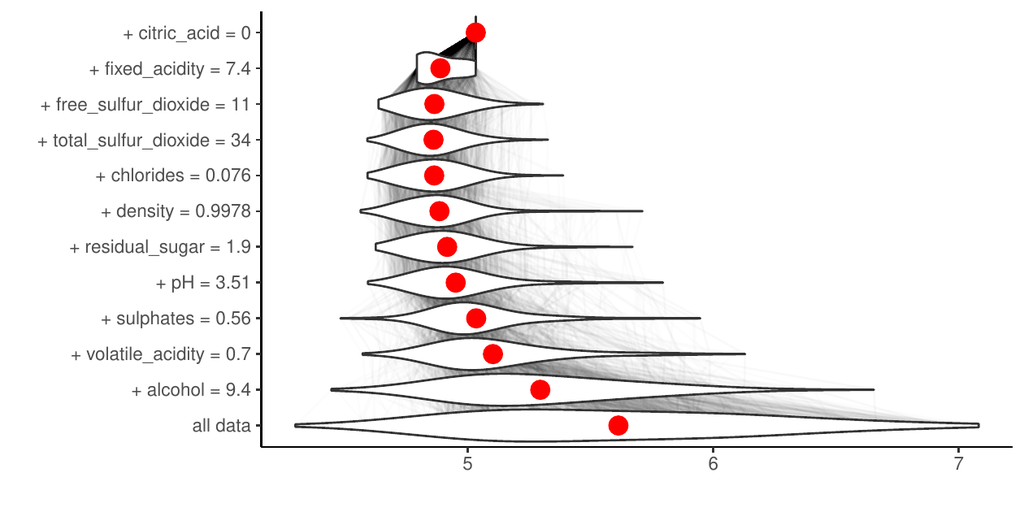

Figure 1: An illustration of algorithm 2. Each row in this plot correspond to a distribution of model scores $f(x)|x_{IndSet} = x^{new}_{IndSet}$ for different sets of $IndSet$ indexes. Initially $IndSet = \{1, \ldots, p\}$ and in each step single variable is removed from this set. Labels on the left-hand side of the plots show which variable is removed in a given step. Red dots stand for conditional average - an estimate of relaxed predictions $f^{IndSet}(x^{new})$. Violin plots summarize conditional distributions of scores while gray lines show how model predictions change for particular observations between consecutive relaxations. This plot is based on `wine` dataset described in section 5.

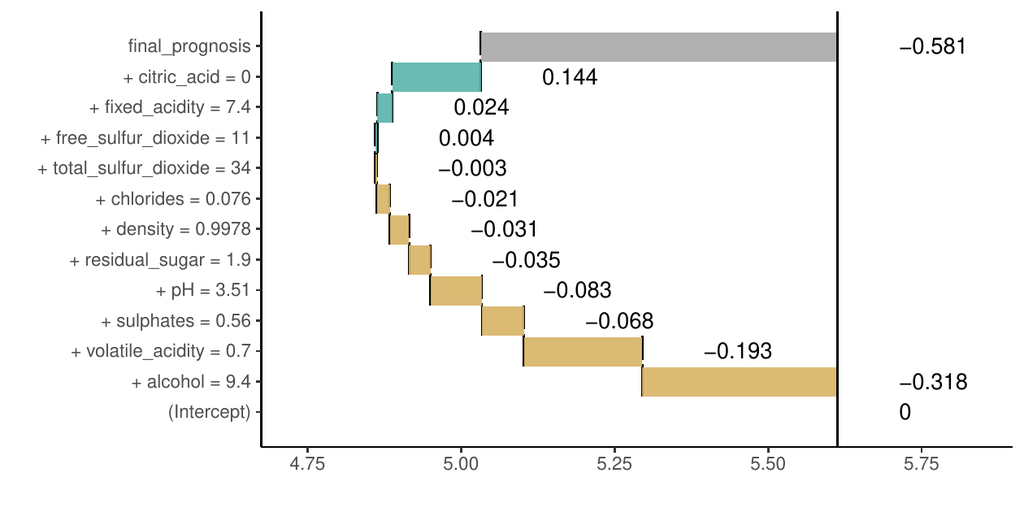

Figure 2: Break Down Plot for decomposition identified in Figure 1. Beginning and end of each rectangle corresponds to relaxed prediction (red dot in Figure 1) with and without a particular feature. This plot is based on `wine` dataset described in section 5.

# Case study: How good is this red wine?

Wine quality data (Cortez et al. 2009) is a well-known dataset which is commonly used as an example in predictive modeling. The main objective associated with this dataset is to predict the quality of some variants of Portuguese *Vinho Verde* on the basis of 11 chemical properties. A single observation from the dataset can be found in Table 1. According to the results from the original article, the Support Vector Machine (SVM) model performs better than other models including linear regression, neural networks and others.

In this section we will show how *live* package can be used to fit linear regression model locally and generate a visual explanation for the black box model as well as how *breakDown* package can be used to attribute parts of the final prediction to particular features. This example will focus on a regression problem, but since both methods are supposed to be model-agnostic, classification problems are treated in the same way by using scores (probabilities) rather than predicted classes.

Table 1: The fifth observation in wine quality dataset. D denotes density, $\text{Cl}^{-}$ stands for chlorides, "res." for residual and $\text{SO}_{4}^{2-}$ for sulphates.

| fixed acidity | volatile acidity | citric acid | res. sugar | $\text{Cl}^{-}$ | free $\text{SO}_{2}$ | total $\text{SO}_{2}$ | D | pH | $\text{SO}_{4}^{2-}$ | alcohol |  |
| --- | --- | --- | --- | --- | --- | --- | --- | --- | --- | --- | --- |
| 7.40 | 0.70 | 0.00 | 1.90 | 0.08 | 11.00 | 34.00 | 1.00 | 3.51 | 0.56 | 9.40 |  |

The SVM model[^2] used in this example is trained with the use of [*e1071*](https://CRAN.R-project.org/package=e1071) package (Meyer et al. 2018). We do not perform hyperparameter’s tuning as the model performance is not relevant in this use-case.

```r
library("e1071")
data(wine, package = "live")
wine_svm_model <- svm(quality~., data = wine)
```

Different approaches for explaining single predictions are illustrated on the basis of the prediction for the fifth wine from this dataset, the one presented in table 1. The actual quality of this wine is 5, while the quality predicted by the SVM model is $5.03$.

```r
predict(wine_svm_model, wine[5, ])
##        1
## 5.032032
```

## The *live* package

The *live* package approximates black box model (here SVM model) with a simpler white box model (here linear regression model) to explain the local structure of a black box model and in consequence to assess how features contribute to a single prediction.

To do this, we first need to generate artificial observations around the selected observation $x^{new}$ for local exploration. We use `sample_locally` function from *live* package.

```r
library("live")
library("mlr")
wine_sim <- sample_locally(data = wine,
                           explained_instance = wine[5, ],
                           explained_var = "quality",
                           size = 2000,
                           seed = 17)
wine_sim_svm <- add_predictions(wine_sim, wine_svm)
nc <- which(colnames(wine) == "quality")
```

If multiple models are to be explained, there is no need to generate multiple *artificial* datasets. Predictions of each model on a single simulated dataset can be added with the use of `add_predictions` function. A different object should be created for each model, but the same result of a call to `sample_locally` function should be used as the `to_explain` argument. Black box model can be passed as a model object or as a name of *mlr* learner. While the object created by `sample_locally` function stores the dataset, name of the response variable and other metadata, the object returned by `add_predictions` function also stores the fitted black box model. The result of applying `sample_locally` functions does not contain the response but the result of `add_predictions` contains a column with model predictions, which has the same name as the response in the original dataset. The `seed` argument is passed to `set.seed` function to ensure reproducibility, though our experience with this approach shows that the results are stable.

Once the artificial data points around $x^{new}$ are generated, we may fit the white box model to them. In this example we fit a linear regression model using `fit_explanation` function[^3].

```r
wine_expl_live <- fit_explanation(wine_sim_svm)
```

This function returns a native *mlr* object. The model object (for example, `lm` object) can be extracted with the use of `getLearnerModel` function.

The white box model `wine_expl` approximates the black box model `wine_svm_model` around $x^{new}$. Coefficients of this model can be presented graphically with the generic `plot` function for class `live_explainer`. See the corresponding Forest Plot in Figure 3 and the corresponding Waterfall Plot in Figure 4.

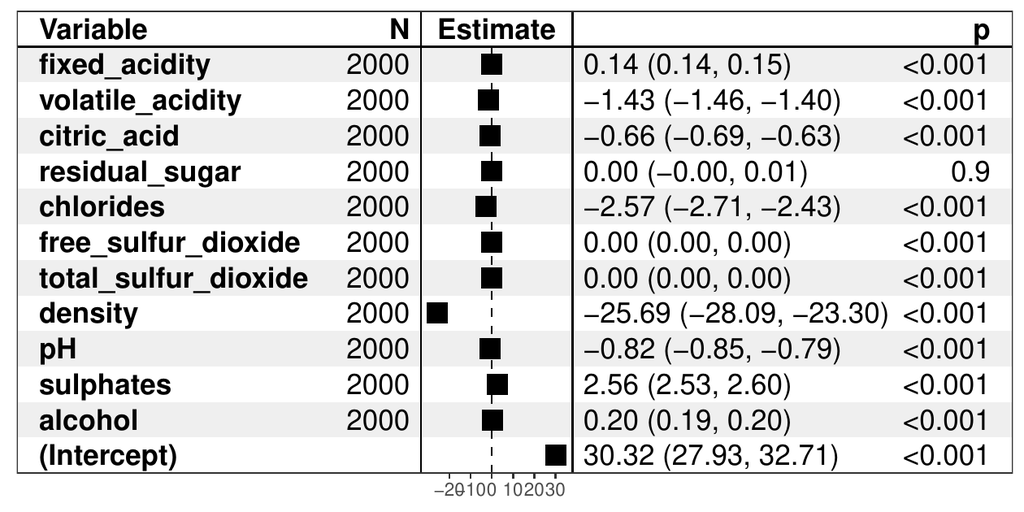

Figure 3: Forest plot for a linear white box model that approximates the black box model.

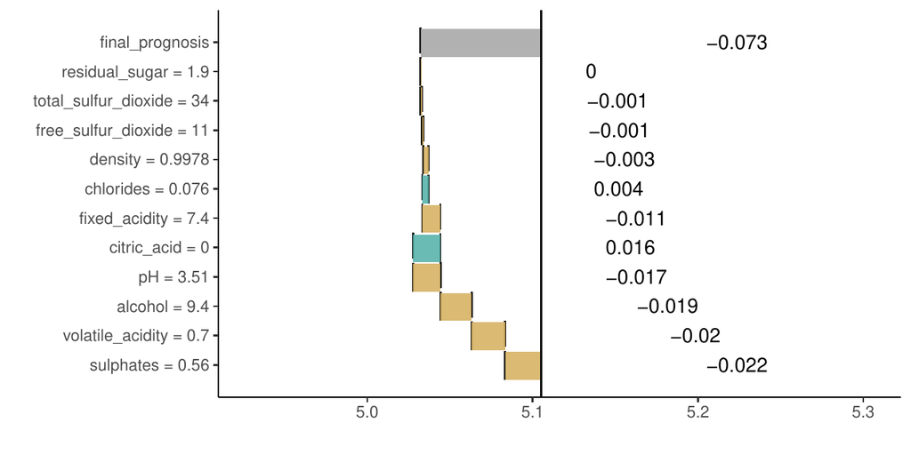

Figure 4: Waterfall plot for additive components of linear model that approximates the black box model around $x^{new}$.

```r
plot(wine_expl, type = "forest")
plot(wine_expl, type = "waterfall")
```

In case of datasets with larger number of variables, we could obtain sparse results by setting `selection = TRUE` in the `fit_explanation` function. This option allows for performance of variable selection based on LASSO implemented in [*glmnet*](https://CRAN.R-project.org/package=glmnet) (J. Friedman, Hastie, and Tibshirani 2010; Simon et al. 2011). When using Generalized Linear Model or Elastic Net as a white box model it is possible to set `family` argument to one of the distribution families available in `glm` and `glmnet` functions via `response_family` argument to `fit_explanation`.

As mentioned, other interpretable models are suitable as local explanations, too. In particular, decision trees can be used to visualization interactions between variables. It is enough to select a different white box model while calling `fit_explanation` function.

```r
wine_expl_tree <- fit_explanation(wine_sim_svm, "regr.ctree", kernel = identity_kernel,
                                  hyperpars = list(maxdepth = 2))
```

Kernel is set to identity, because trees built by *party* package cannot handle non-integer weights. The result is the following decision tree in Figure 5.

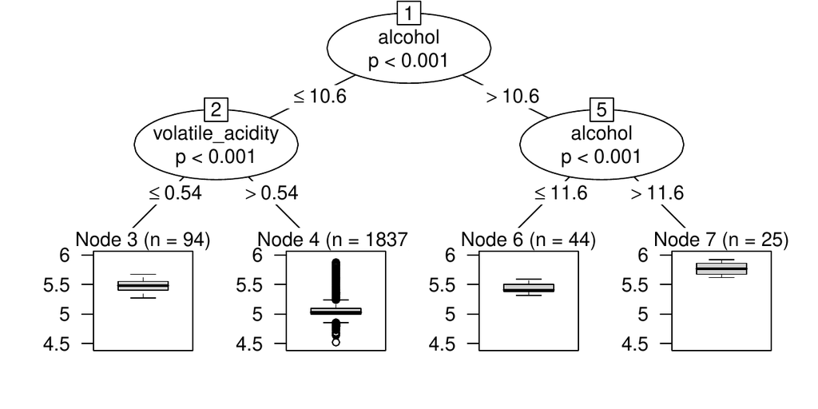

Figure 5: Decision tree that approximates the black box model around $x^{new}$.